# Life in Prison

# British prisons and standards of treatment

The analysis will be based on data from the Ministry of Justice’s open database, as well as the HMPI’s reports (PDF files).

## Deaths in custody from the Ministry of Justice open data website

The dataset includes deaths since 1978. For some reason (?), there is a lot of detail on self-inflicted deaths but very little on natural deaths. (https://data.justice.gov.uk/prisons)

```r
deaths.in.custody <- read_ods('safety-in-custody-Deaths-dec-18.ods', sheet = '1_1_Deaths_by_calendar_year', skip = 3)
```

```r
names(deaths.in.custody)[1] <- 'category'

deaths.in.custody %>%
  filter(!is.na(`1978`)) %>%
  mutate(category = recode(category, 'Other3' = 'Other', 'POPULATION4' = 'Population')) -> deaths.in.custody


# prepare data for plot
# use the rate to standardise
deaths.rate <- deaths.in.custody[(7:10),] %>%
  gather(key = 'year', value = 'rate', -category) %>%
  mutate(rate = as.numeric(rate), year = as.numeric(year))
```

### Death rate in custody in English and Welsh prisons (all causes included)

Note: “Gibson” used as Windows font

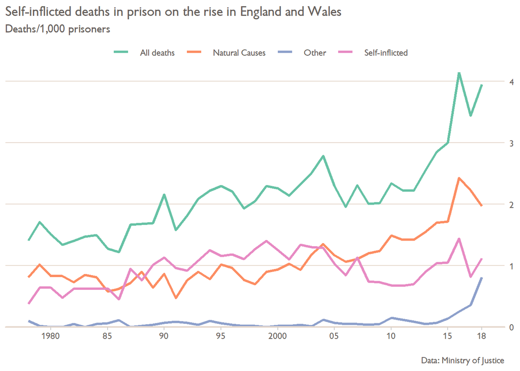

## Compliance with recommendations

Recommendations data extracted from HMPI annual reports tables.

```r
rec.achieved <- read.csv('recommendations.csv')

# this contains totals for all recommendations made and their outcome
# breakdown by recommendation only for recent years
# details will be removed for analysis


rec.achieved %>%
  clean_names() %>%
  gather(key = 'recommendation.type', value = 'rate', -year) %>%
  mutate(recommendation.type = factor(recommendation.type))-> rec.tidy


rec.total <- rec.tidy %>%
  filter(recommendation.type %in% c('total_achieved', 'total_partial', 'total_not')) %>%
  mutate(recommendation.type = trimws(recommendation.type)) %>%
    mutate(recommendation.type = factor(recommendation.type, levels = c('total_achieved', 'total_partial', 'total_not'), ordered = TRUE)) %>%
  filter(year %in% c('2013/14', '2017/18')) %>%
  mutate(recommendation.type = recode(recommendation.type, 'total_achieved' = 'Achieved', 'total_partial' = 'Partially achieved', 'total_not' = 'Not achieved' ))
```

Comparison between 2013/14 and 2017/18 (latest year available, published July 2018)

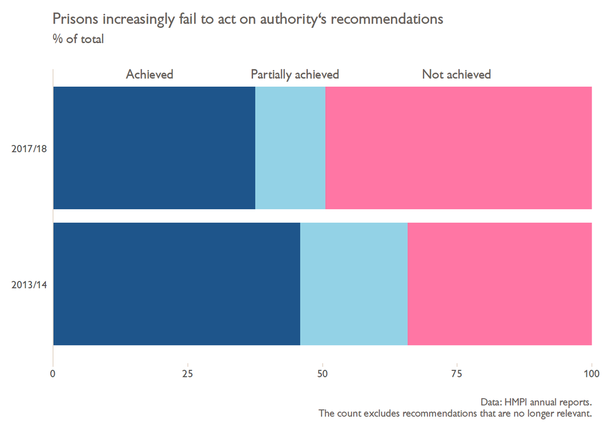

To be fair, this chart indicates an interesting trend but could be easily contested. Each prison receives an inspection at least every 5 years, which means numbers of recommendations are only partly comparable and trends cannot be statistically significant. Longer manual work might lead to compare each prison’s performance over time (even then, it all depends on changes in criteria used).

### Prison performance year by year

A cursory comparison between public vs. private prisons (excluding immigration centres, police custody, etc.) A lookup table will be used to associate prisons and ownerships in the score and recommendation tables. The work is very rough and would need further review (prisons may be recorded under different names; e.g. Usk/Prescoed may appear separately). All the tables are extracted from the PDF reports with Tabula.

```r
prison.lookup <- read.csv('prison_lookup.csv')




recs.1718 <- read.csv('recs_1718.csv') %>%
  clean_names() %>%
  left_join(prison.lookup, by = 'establishment') %>%
  select(establishment, contains('total'), -total, Ownership, type) %>%
  gather(key = rec_type, value = count, -establishment, -Ownership, -type)
```

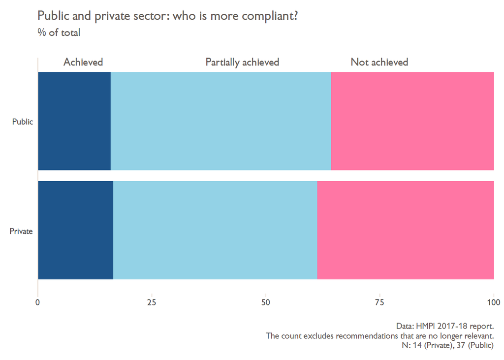

```r
ggplot(recs.1718, aes(Ownership, as.numeric(count), fill = rec_type)) + geom_col(position = 'fill') +
   scale_fill_manual(values = c( '#FF76A4', '#93D2E6', '#1E558B')) +
   annotate("text", x=2.55, y=c(0.1, 0.45, 0.75), label= c('Achieved', 'Partially achieved',"Not achieved"), family = 'Gibson', colour = '#66605C') +
  scale_y_continuous(labels = c(0, 25, 50, 75, 100), expand = c(0, 0)) +
  scale_x_discrete(expand = c(.58, 0)) +
  labs(x = NULL, y = NULL, title = "Public and private sector: who is more compliant?", subtitle = '% of total', caption = 'Data: HMPI 2017-18 report.\nThe count excludes recommendations that are no longer relevant.\nN: 14 (Private), 37 (Public)') +
  coord_flip() +
  theme_minimal() +
  theme(legend.position = 'none', panel.grid = element_blank(), text = element_text(family = 'Gibson', colour = '#66605C'), axis.ticks.x = element_line(colour= '#e6d9ce'), axis.line.y = element_line(colour = '#e6d9ce'), plot.margin = margin(t = 10, r = 10, b = 10, l = 10, unit = 'pt'), plot.subtitle = element_text(margin = margin(t = 0, r = 0, b = 20, l = 0)), plot.caption = element_text(margin = margin(t = 15, unit = 'pt')))
```

## Prisoner violence: exploring data

Data is taken from the HMPPS open database. This was originally part of an .ods file but was copied and cleaned in Excel (column names would have been too complex to rename). The aim is to find the best and worst performers against a number of parameters and look at the recommendations/reports to find the main issues. Data is from 2017/2018 (though inspections occurred at different times)

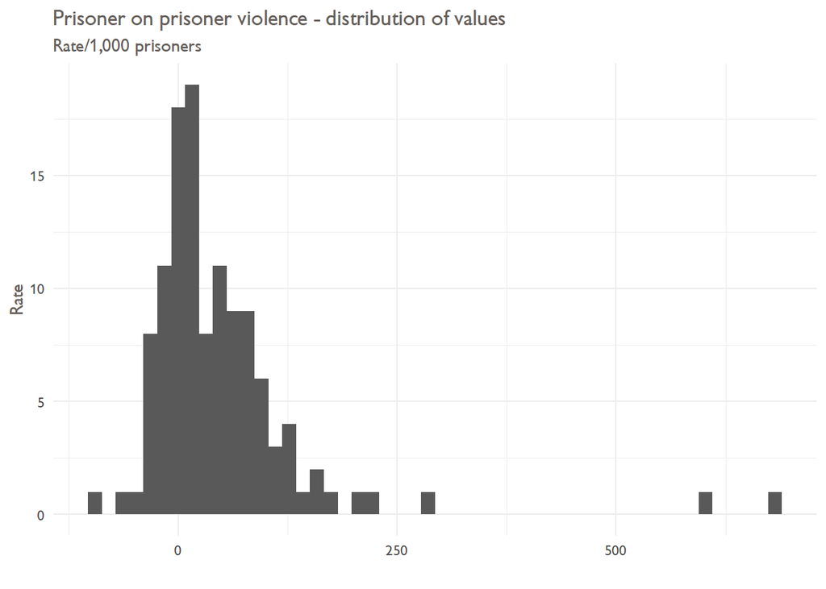

```r
cpt.1718 <- read.csv('parameters_1718.csv', na = c('', '-'))

# distribution of values for prisoner-on-prisoner-violence
cpt.1718 %>%
  filter(!is.na(assaults_prisoner_change)) %>%
  arrange(desc(assaults_prisoner_change)) %>%
  ggplot(aes(assaults_prisoner_change)) + geom_histogram(bins = 50)+
  theme_minimal() +
  labs(title = 'Prisoner on prisoner violence - distribution of values', subtitle = 'Rate/1,000 prisoners', x = '', y = 'Rate') +
  theme(text = element_text(family = 'Gibson', colour = '#66605C'))
```

It appears that, in most instances, levels of violence have remained stable or have slightly increased. There are a few notable outliers - let’s find out who they are.

Visualising the top and worst performers:

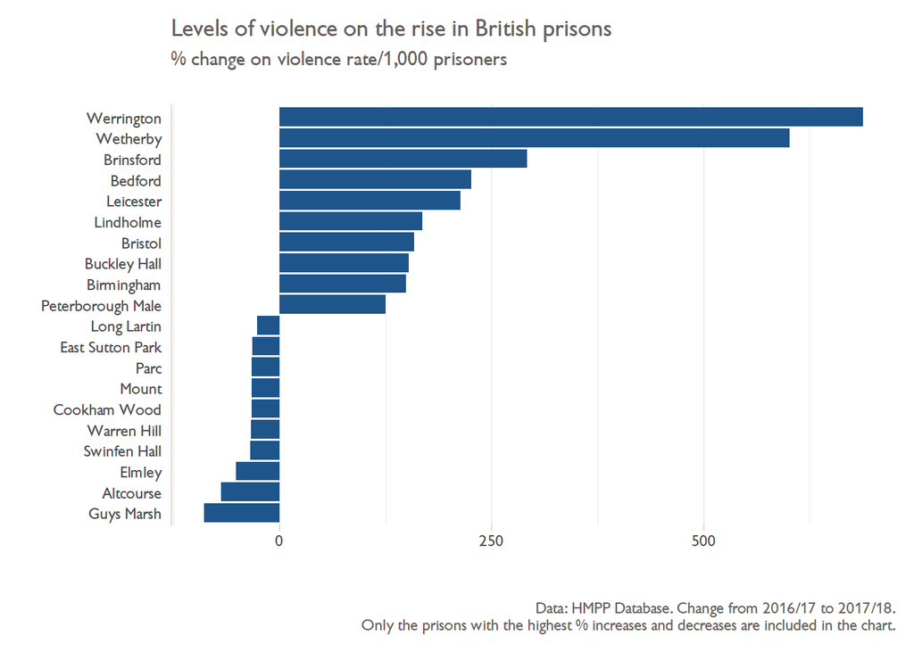

```r
# dirty code, look for something cleaner

pr_violence_top10 <- cpt.1718 %>%
  filter(!is.na(assaults_prisoner_change)) %>%
  arrange(desc(assaults_prisoner_change)) %>%
  top_n(10, assaults_prisoner_change)

pr_violence_tb10 <- cpt.1718 %>%
  filter(!is.na(assaults_prisoner_change)) %>%
  arrange(desc(assaults_prisoner_change)) %>%
  top_n(-10, assaults_prisoner_change) %>%
  rbind(pr_violence_top10, .)

ggplot(pr_violence_tb10, aes(reorder(establishment, assaults_prisoner_change), assaults_prisoner_change)) + geom_col(fill = '#1E558B') +
  coord_flip() +
  theme_minimal() +
  labs(x = '',y = '', title = 'Levels of violence on the rise in British prisons', subtitle = '% change on violence rate/1,000 prisoners', caption = 'Data: HMPP Database. Change from 2016/17 to 2017/18.\nOnly the prisons with the highest % increases and decreases are included in the chart.') +
  theme(panel.grid.major.y = element_blank(), text = element_text(family = 'Gibson', colour = '#66605C'), axis.ticks.x = element_line(colour= '#e6d9ce'), axis.line.y = element_line(colour = '#e6d9ce'), plot.margin = margin(t = 10, r = 10, b = 10, l = 10, unit = 'pt'), plot.subtitle = element_text(margin = margin(t = 0, r = 0, b = 20, l = 0)), plot.caption = element_text(margin = margin(t = 15, unit = 'pt')))
```

So what’s happening at Werrington? It doesn’t look like a glitch in the data, as Wetherby also displays a similar (concerning) trend. A cursory look at Werrington’s [action plan](https://www.justice.gov.uk/downloads/contacts/hmps/prison-finder/hmyoi-werrington-action-plan.pdf) suggests money could be a factor (recommendations are often refused/partly adopted due to lack of resources). It is not necessarily the main cause, but it doesn’t make things easier. Other issues like staff training should be look into. Note to self: look at other parameters as well. Also: is staff sick leave a valid measure of good performance? (Hint: turnover is increasing)